# Intro to Generalized Additive Models

1 June 2026

## Acknowledgments

Gavin Simpson and colleagues have produced a lot of useful teaching material on GAMs that I’ve made use of here. For example:

[Gavin’s blog](https://fromthebottomoftheheap.net)

[Webinar 1](https://www.youtube.com/live/sgw4cu8hrZM?si=pDEYp2OdKB7guJ8T&t=285)

[Webinar 2](https://youtu.be/Ukfvd8akfco?si=g17GQv2ExA1KA0oO&t=8)

## Goals for today

- Understand what a smoother is and understand the motivation for using a smoother in a model
- Learn how to fit some basic GAMs with splines

## Assumptions of linear models

- Linear relationship between predictor and response
- Observations are a random sample from the population
- The predictor(s) are known without measurement error
- If 2+ predictors, they are independent of each other
- Errors are IID: \(\epsilon_i \sim \text{N} (0, \sigma); ~ \text{Cov}(\epsilon_i, \epsilon_{j \neq i}) = 0\)

## Non-linear relationships?

- For Gaussian LMs we assume a linear relationship between predictor and response
- For non-Gaussian GLMs, we assume a linear relationship between link(predictor) and response
- What if we think the relationship is *non-linear*?

## Non-linear data

### Sea surface temperature anomalies from Hadley Centre (UK Met Office)

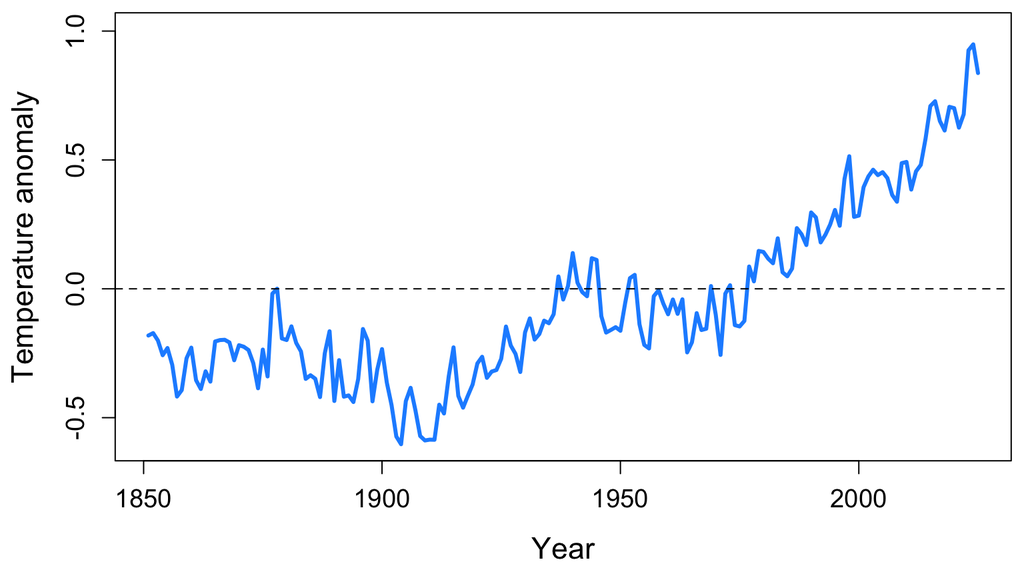

## Non-linear relationships

### A degree-10 (decic) polynomial fit to the data

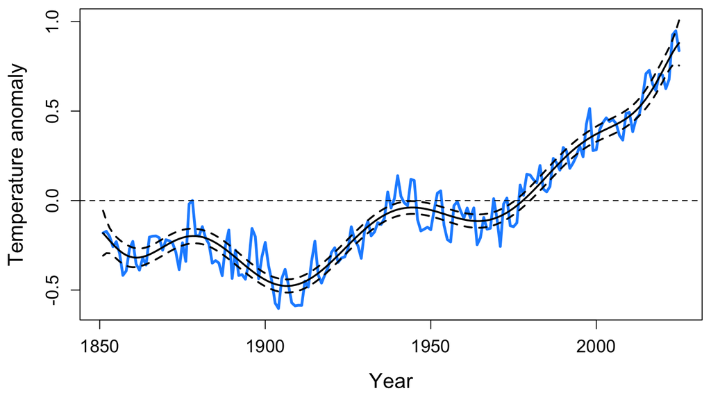

## Generalized additive models

We seek a model that allows for some smooth **and** non-linear relationship between year and temperature

## Generalized additive models

We seek a model that allows for some smooth **and** non-linear relationship between year and temperature

A generalized additive model is an extension of the GLM with a predictor that is a sum of smoothed (and possibly unsmoothed) terms:

\[ y_i = \beta_0 + \sum_j s_j(x_{j,i}) + \sum_k \beta_k x_{k,i} + \epsilon_i \]

## Type of GAMs

### LOESS (LOcally Estimated Scatterplot Smoothers)

Fit many local (weighted) regressions within a sliding window

LOESS fitting is available in the `mgcv::gam()` function

## Type of GAMs

### LOESS (LOcally Estimated Scatterplot Smoothers)

Pros

- Pretty simple and easy to understand

## Type of GAMs

### LOESS (LOcally Estimated Scatterplot Smoothers)

Pros

- Pretty simple and easy to understand

Cons

- Size of the window (and hence the degree of smoothness) matters, but there isn’t much theory to help you choose
- If we make the window big, we’ll essentially get a linear regression, if we make it small, we will overfit (or “under-smooth”)
- LOESS isn’t very reliable near the ends of the data

## Type of GAMs

### Splines

- Much more flexible and adaptable than LOESS smoothing
- Can be applied to lots of non-Gaussian error distributions & with random effects
- The degree of smoothness can be estimated as part of model fitting via restricted maximum likelihood or generalized cross validation

## What are splines?

Splines are *basis expansions*

For example, a polynomial is one type of basis expansion:

\[ \begin{aligned} x^0 &= 1\\ x^1 &= x\\ x^2 &= x^2\\ x^3 &= x^3\\ &~~\vdots \end{aligned} \]

## What are splines?

In a basis expansion

- We call each of the simpler functions a *basis function*
- The set of simpler functions, \(b_k\), is called a *basis*

## What are splines?

When we model using splines, each of the \(b_k\) has a coefficient \(\beta_k\)

The spline is the sum of these functions (weighted by \(\beta_k\) and evaluated at \(x\)):

\[ s(x)=\sum_k \beta_k b_k(x) \]

## Types of splines

One of the easiest to think about is a cubic regression spline

- \(X\) is divided into intervals (defined by the number of “knots”)

## Types of splines

One of the easiest to think about is a cubic regression spline

- \(X\) is divided into intervals (defined by the number of “knots”)
- In each interval, we fit a cubic polynomial

\[ y_i = \beta_0 + \beta_1 x_i + \beta_2 x_{i}^2 + \beta_3 x_{i}^3 \]

- The fitted values per interval are stuck together to form the curve
- The intervals connect at the knots
- To obtain a smooth connection at the knots, certain conditions are imposed

## How do we go from a basis to a model fit?

We want to allow for a function that is “wiggly”, but not too wiggly

- A function that is too wiggly would indicate that we are overfitting (or undersmoothing)
- We seek a model that explains the general underlying process while not overfitting the nuances of an individual dataset
- We need just the right level of wiggliness, but how do we measure wiggliness?

## Measuring wiggliness

First, consider the squared second derivative:

\[ \int_{\mathbb{R}}[f'']^2dx \]

This is the rate of change in the slope - more wiggliness will result in a higher rate of change in the slope

We estimate this with:

\[ \int_{\mathbb{R}}[f'']^2dx=\beta^TS\beta \]

where \(S\) is a penalty matrix, derived from our weighted basis functions

## Measuring wiggliness

We now use this to penalize our likelihood function

\[ log(\mathcal{L_p{|\beta}})=log(\mathcal{L{|\beta}}) - \lambda\beta^TS\beta \]

where \(\lambda\) is a smoothness parameter, indicating how much we penalize wiggliness

We will maximize this penalized likelihood

## Penalty on lambda affects wiggliness

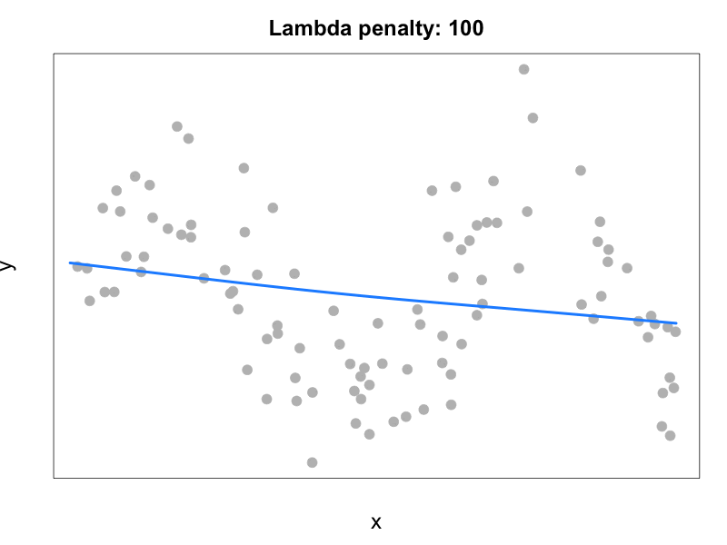

## More on wiggliness

We set \(k\) as the maximum wiggliness (this determines the number of knots)

but what should we choose for the smoothness parameter \(\lambda\)?

## Choosing \(\lambda\)

- `method = "REML"` uses a relationship between random effects and smoothers – we can think of \(\lambda\) as a prior on the spline coefficients
- We can also use generalized cross-validation
- There is reason to think that “REML” works best ([Wood 2011](https://doi.org/10.1111/j.1467-9868.2010.00749.x))

## What kind of splines?

**thin plate spline** `s(X, bs = 'tp')` [default in `mgcv::gam()`]

- one knot for every unique value of \(x\)

## What kind of splines?

**thin plate spline** `s(X, bs = 'tp')` [default in `mgcv::gam()`]

- one knot for every unique value of \(x\)

**cubic regression spline** `s(X, bs = 'cr')`

- widely used, especially useful for big datasets

## What kind of splines?

**thin plate spline** `s(X, bs = 'tp')` [default in `mgcv::gam()`]

- one knot for every unique value of \(x\)

**cubic regression spline** `s(X, bs = 'cr')`

- widely used, especially useful for big datasets

**cyclic spline** `s(X, bs = 'cc')`

- join the ends of the spline

## What kind of splines?

**thin plate spline** `s(X, bs = 'tp')` [default in `mgcv::gam()`]

- one knot for every unique value of \(x\)

**cubic regression spline** `s(X, bs = 'cr')`

- widely used, especially useful for big datasets

**cyclic spline** `s(X, bs = 'cc')`

- join the ends of the spline

**splines on a sphere** `s(X, bs = 'sos')`

*many* others in `mgcv::gam()` for special situations

## Fitting a GAM

Let’s fit a GAM to the global temperature data using splines

```r
ex_gam_fit <- mgcv::gam(temp ~ s(year), data = sst, method = 'REML')
```

## Summary of GAM fit

```
##
## Family: gaussian
## Link function: identity
##
## Formula:
## temp ~ s(year)
##
## Parametric coefficients:
##              Estimate Std. Error t value Pr(>|t|)
## (Intercept) -0.056439   0.006859  -8.229 5.36e-14 ***
## ---
## Signif. codes:  0 '***' 0.001 '**' 0.01 '*' 0.05 '.' 0.1 ' ' 1
##
## Approximate significance of smooth terms:
##           edf Ref.df     F p-value
## s(year) 8.515  8.933 248.8  <2e-16 ***
## ---
## Signif. codes:  0 '***' 0.001 '**' 0.01 '*' 0.05 '.' 0.1 ' ' 1
##
## R-sq.(adj) =  0.927   Deviance explained = 93.1%
## -REML = -148.15  Scale est. = 0.0082328  n = 175
```

## GAM fit to the data

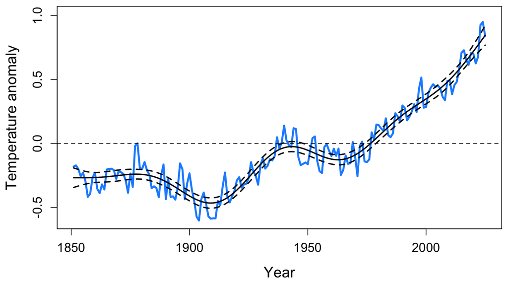

## Another example

### Chinook salmon survival from homework #4

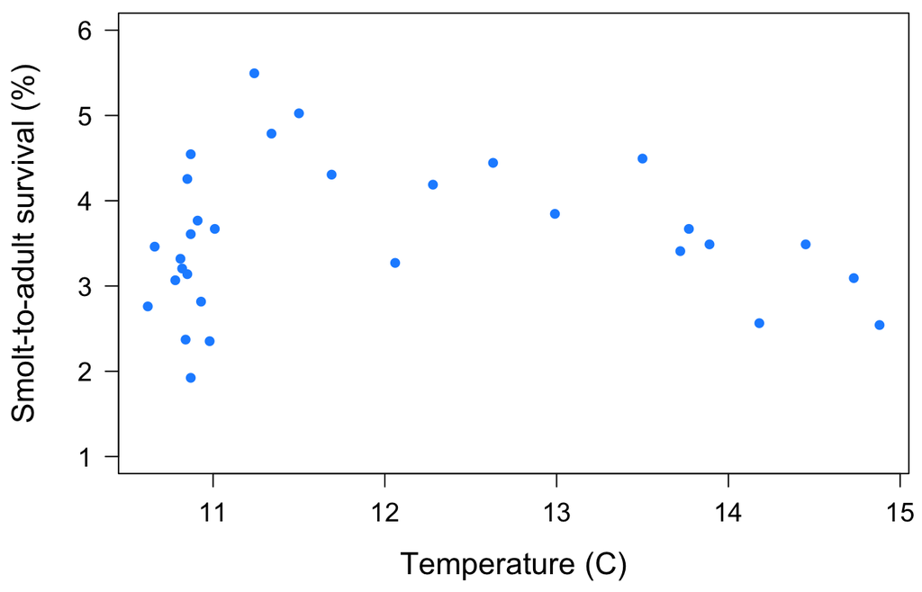

## Fit a GAM

```r
## fit GAM with spline for temp
ex_gam_fit <- gam(sar ~ s(temp),
              data = chinook, method = "REML")
```

## Model fit and data

```
##
## Family: gaussian
## Link function: identity
##
## Formula:
## sar ~ s(temp)
##
## Parametric coefficients:
##             Estimate Std. Error t value Pr(>|t|)
## (Intercept)   3.5605     0.1291   27.58   <2e-16 ***
## ---
## Signif. codes:  0 '***' 0.001 '**' 0.01 '*' 0.05 '.' 0.1 ' ' 1
##
## Approximate significance of smooth terms:
##          edf Ref.df     F p-value
## s(temp) 2.94   3.63 3.387  0.0304 *
## ---
## Signif. codes:  0 '***' 0.001 '**' 0.01 '*' 0.05 '.' 0.1 ' ' 1
##
## R-sq.(adj) =  0.273   Deviance explained = 34.4%
## -REML = 36.917  Scale est. = 0.51672   n = 31
```

## Model fit and data

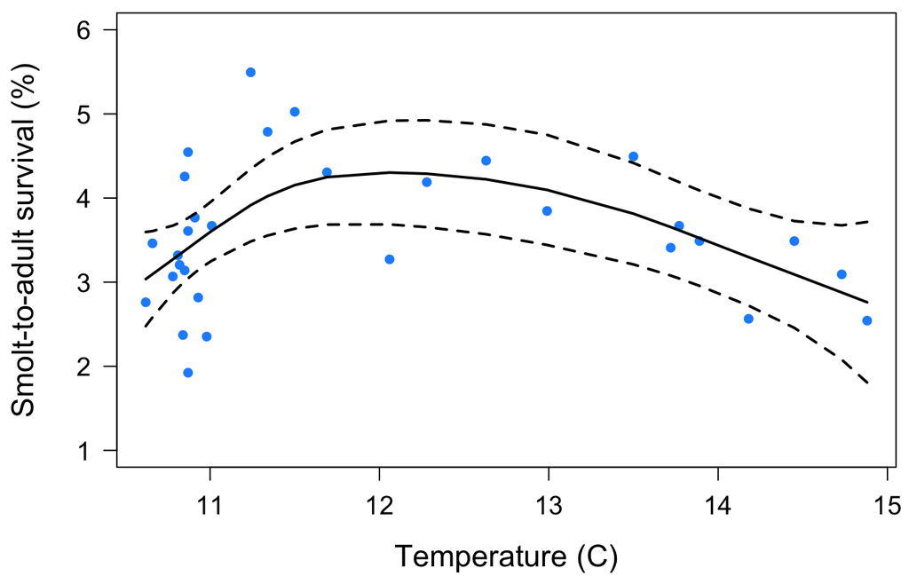

## GLM with quadratic term

```r
ex_glm_fit <- glm(cbind(adults, smolts - adults) ~ temp + I(temp^2),
                  family = binomial(link = "logit"),
                  data = chinook)
```

## Quadratic model fit and data

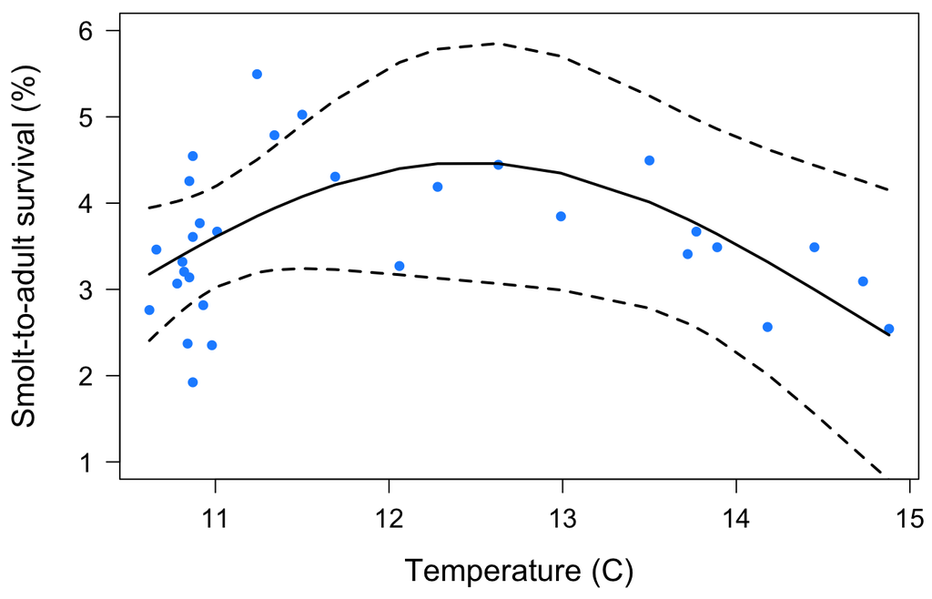

## Next time

- Model checking
- More on model selection
- The flexibility of GAMs